# Differential expression - NCPI

Michael Tassia

2024-07-09

## Outline

- Introduction
- Environment preparation
- `DESeq2` analysis, results, & visualization
  - Visualizing autosomes

## Introduction

In this document, we will describe the procedures used to generate differential gene expression (DGE) results for the AMR continental group (as a proxy for individuals with Latin American ancestry).

The analysis presented below uses MAGE, an RNA-seq data set generated from lymphoblastoid cell lines derived of 731 individuals from the [1000 Genomes Project](https://doi.org/10.1038/nature15393) (1KGP). We will describe the formats of input from the MAGE data set below as they become relevant. Additionally, the `DESeq2` pipeline described below broadly aligns with that described by the `DESeq2` vignette (with some modifications to account for the complex design formula and factor contrasts to extract differential expression of the AMR continental group).

## Environment preparation

First, load/install the packages necessary for preparation, analysis, and visualization.

With packages loaded, we’ll next prepare the input and metadata for `DESeq2`. We’ll load three forms of data:

1. **Expression pseudocounts** (`*quant.sf.gz`) generated with `Salmon` for each of the 731 individuals (779 total libraries with technical replicates) included in MAGE (MAGE used [GENCODE v38](https://www.gencodegenes.org/human/release_38.html) for expression quantification).
2. **Metadata** containing the relevant covariates for each individual (i.e. sequencing batch, sex, and population label).
3. A **transcript-to-gene** (`tx2gene`) table to convert transcript-level pseudocounts to gene-level pseudocounts with [`tximport`](https://bioconductor.org/packages/release/bioc/vignettes/tximport/inst/doc/tximport.html)

Importantly, only `population` is used, not `design = ~ population + contGroup + batch + sex`. As each `contGroup` is captured by a combination of `population` factor levels (and thus is colinear with `contGroup`), including both `contGroup` and `population` results in a model matrix that violates the full rank requirements of `DESeq2`’s regression steps. If both variables are included in the design formula, `DESeqDataSetFromTximport` will halt and return an error. Because `population` provides finer resolution to isolate the differential expression effects for each AMR-contained `population` label, we’ll use `population` instead of `contGroup`.

## `DESeq2` analysis, results, & visualization

In the following code blocks, we’ll perform differential expression analysis using the `DESeq` command. To learn more about the `DESeq2` methods/approach, please see the vignette: `vignette("DESeq2")`.

Below, we will parallelize using `MulticoreParam` from the `BiocParallel` package. **Running the `DESeq` command is the most computationally-intensive step of this protocol.**

```r
#Register cores for parallel compute
register(MulticoreParam(6)) #This value can be adjusted according to the number of cores available

#Run DESeq2 (longest step)
deseq.obj<-DESeq(object = deseq.obj,
                 parallel=TRUE)
```

```
## using 'avgTxLength' from assays(dds), correcting for library size
```

```r
#Print
deseq.obj
```

```
## class: DESeqDataSet
## dim: 60230 731
## metadata(1): version
## assays(6): counts avgTxLength ... H cooks
## rownames(60230): ENSG00000000003.15 ENSG00000000005.6 ...
##   ENSG00000288724.1 ENSG00000288725.1
## rowData names(186): baseMean baseVar ... deviance maxCooks
## colnames(731): GM06985 GM07000 ... HG04227 HG04235
## colData names(7): library_id sample_id ... sex runsCollapsed
```

Following the code block above, `deseq.obj` contains the analysed results from `DESeq2`. From this object, we can perform a Wald Test for the AMR continental group against the global expression average of all other continental groups (i.e., AFR, EUR, SAS, and EAS).

If our design formula were simpler (e.g., a *condition* categorical variable where the levels are *treatment* and *control*), we could simply use the following command:

```
results(object=deseq.obj,contrast=c("condition","treatment","control"))
```

However, as our regression formula is more complex (including two categorical variables with >2 levels each) and our focal condition (AMR continental group label) is an assembly of the CLM, MXL, PEL, and PUR population labels, we will have to manually construct a contrast vector for our analysis.  
The `Model_Matrix` object generated below contains the expanded model matrix capturing each factor level encoded as a dummy-variable. This will become important as we need to construct a numeric contrast vector to extract the AMR vs. non-AMR differential expression results later. For more information on extracting DGE results with multi-level factors, [please see this tutorial](https://github.com/tavareshugo/tutorial_DESeq2_contrasts/blob/main/DESeq2_contrasts.md).

```r
#Extract model matrix
Model_Matrix<-model.matrix(design(deseq.obj),
                           colData(deseq.obj))

#Print
Model_Matrix[1:5,1:5]
```

```
##         (Intercept) populationASW populationBEB populationCDX populationCEU
## GM06985           1             0             0             0             1
## GM07000           1             0             0             0             1
## GM11919           1             0             0             0             1
## GM11930           1             0             0             0             1
## GM11932           1             0             0             0             1
```

Next, we need to extract the coefficient matrix for each population label. The following loop will generate an object for each level of `deseq.obj$population`.

```r
#Generates a coefficient matrix for each subpop
population_list<-levels(deseq.obj$population)
for (id in population_list) {
  var_name<-paste(id,"_coefmat",sep="") #Programatically prepare variable names
  coef_matrix<-colMeans(Model_Matrix[deseq.obj$population == id,])
  assign(var_name,coef_matrix) #Assign variable name to object
  remove(var_name,coef_matrix,id)
}
```

Each of the coefficient matrices generated with the loop above captures the factor levels present within each population label (n=26). For example, as the sequencing-batching structure of the MAGE project was designed to spread population labels evenly across each sequencing batch, the `batch` dummy-variable coefficients will never be `1` for any single coefficient matrix (as other populations also possess samples in each focal sequencing batch). Furthermore, the intercept for each coefficient matrix should always `= 1`, as each gene’s intecept captures the experiment-wide mean count.

```r
#Viewing batch coefficients for PEL
PEL_coefmat[grepl(x=names(PEL_coefmat),pattern = "batch")]
```

```
##     batch2     batch3     batch4     batch5     batch6     batch7     batch8
## 0.07142857 0.07142857 0.03571429 0.07142857 0.03571429 0.07142857 0.07142857
##     batch9    batch10    batch11    batch12    batch13    batch14    batch15
## 0.07142857 0.07142857 0.03571429 0.07142857 0.10714286 0.03571429 0.07142857
##    batch16    batch17
## 0.07142857 0.00000000
```

```r
#Viewing intercept coefficient for PEL
PEL_coefmat[1]
```

```
## (Intercept)
##           1
```

Next, we’ll use linear combinations of these coefficient matrices to generate the mean expression coefficient matrices of their parent continental group labels:

```r
##Create contGroup coefficient matrices from population coefficient matrices
AFR_contGroup_coefmat<-(ACB_coefmat+
                          ASW_coefmat+
                          ESN_coefmat+
                          GWD_coefmat+
                          LWK_coefmat+
                          MSL_coefmat+
                          YRI_coefmat)/7
AMR_contGroup_coefmat<-(CLM_coefmat+
                          MXL_coefmat+
                          PEL_coefmat+
                          PUR_coefmat)/4
EAS_contGroup_coefmat<-(CDX_coefmat+
                          CHB_coefmat+
                          CHS_coefmat+
                          JPT_coefmat+
                          KHV_coefmat)/5
EUR_contGroup_coefmat<-(CEU_coefmat+
                          FIN_coefmat+
                          GBR_coefmat+
                          IBS_coefmat+
                          TSI_coefmat)/5
SAS_contGroup_coefmat<-(BEB_coefmat+
                          GIH_coefmat+
                          ITU_coefmat+
                          PJL_coefmat+
                          STU_coefmat)/5

focal_contrast<-AMR_contGroup_coefmat-(AFR_contGroup_coefmat+
                                         EAS_contGroup_coefmat+
                                         EUR_contGroup_coefmat+
                                         SAS_contGroup_coefmat)/4

#Print
focal_contrast[1:5]
```

```
##   (Intercept) populationASW populationBEB populationCDX populationCEU
##    0.00000000   -0.03571429   -0.05000000   -0.05000000   -0.05000000
```

```r
#Cleanup
rm(list = ls(pattern = "coefmat"))
```

Finally, we’ll pass the relevant contrast matrix to `results`. This step can take a few min to run.

```r
#Run AMR vs non-AMR contrast
deseq.res<-results(object = deseq.obj,
                   contrast = focal_contrast,
                   parallel=TRUE)
```

The `deseq.res` object contains the differential expression results for each gene in AMR 1KGP participants vs. the global mean expression among non-AMR participants. These results can be summarized and written to a file using the following commands:

```r
#View DESeq2 results summary
summary(deseq.res,alpha=0.05)
```

```
##
## out of 52008 with nonzero total read count
## adjusted p-value < 0.05
## LFC > 0 (up)       : 1840, 3.5%
## LFC < 0 (down)     : 2258, 4.3%
## outliers [1]       : 21, 0.04%
## low counts [2]     : 23996, 46%
## (mean count < 1)
## [1] see 'cooksCutoff' argument of ?results
## [2] see 'independentFiltering' argument of ?results
```

```r
#Save results as a csv
write_csv(x = as.data.table(deseq.res),
          file = "AMR_DGE.csv",
          col_names = T)
```

For further analysis/visualization of results, `as.data.table(deseq.res)` can be used to extract common metrics of differential expression, including the modeled `baseMean` for each gene (experiment-wide), `log2FoldChange` expression values (effect sizes from the Wald Test), and the FDR-corrected p-values (`padj`). To read more about the `DESeq2` model for FDR-correction and independent filtering, see the [relevant section of the vignette](https://www.bioconductor.org/packages/release/bioc/vignettes/DESeq2/inst/doc/DESeq2.html#independent-filtering-and-multiple-testing).

Below are a couple options for visualization of these results using methods built into `DESeq2` and custom plotting with `ggplot2` (which may provide some more flexibility):

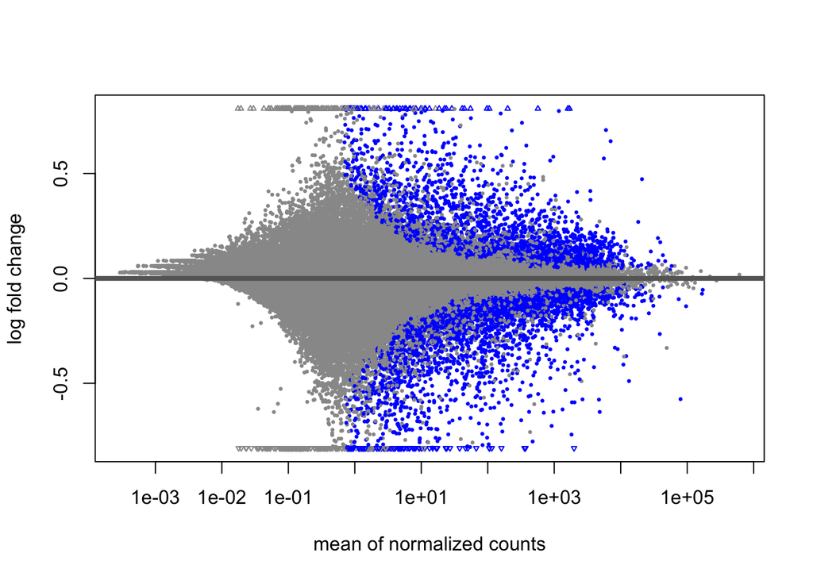

```r
#DESeq2 MA plot
plotMA(deseq.res)
```

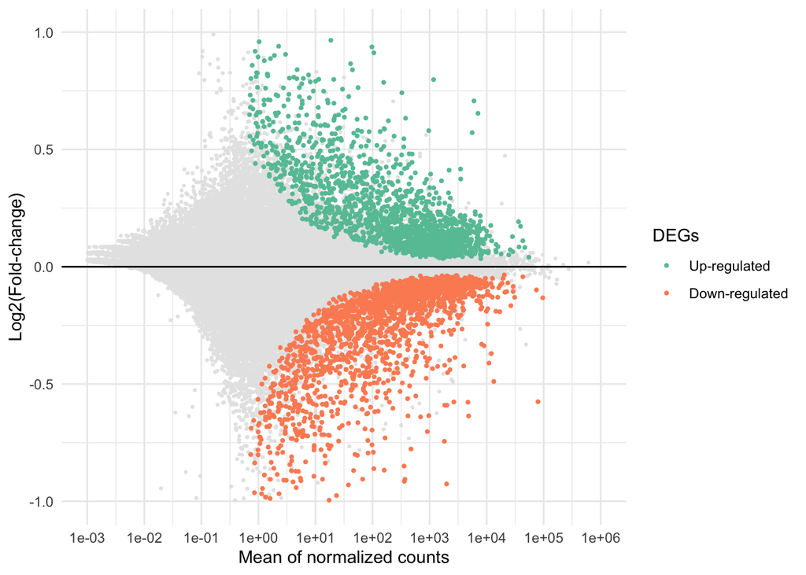

```r
#ggplot2 MA plot
AMR_df <- as.data.table(deseq.res) %>%
  mutate(sig = case_when(padj <= 0.05 & log2FoldChange > 0 ~ factor("Up-regulated"),
                         padj <= 0.05 & log2FoldChange < 0 ~ factor("Down-regulated"),
                         padj > 0.05 ~ factor("none"),
                         is.na(padj) ~ factor("none")))
ggplot(data = AMR_df %>% dplyr::filter(sig == "none"),
       mapping = aes(x=baseMean,
                     y=log2FoldChange)) +
  geom_point(size=0.5,color="gray90") +
  geom_point(data = AMR_df %>% dplyr::filter(sig == "Up-regulated"),
             mapping = aes(x=baseMean,
                           y=log2FoldChange,
                           color=sig),
             size=0.75) +
  geom_point(data = AMR_df %>% dplyr::filter(sig == "Down-regulated"),
             mapping = aes(x=baseMean,
                           y=log2FoldChange,
                           color=sig),
             size=0.75) +
  geom_hline(yintercept=0) +
  scale_x_log10(limits=c(1e-3,1e6),breaks=10^(-3:6)) +
  scale_y_continuous(limits=c(-1,1)) +
  scale_color_brewer(palette="Set2")+
  theme_minimal() +
  labs(x="Mean of normalized counts",y="Log2(Fold-change)",color="DEGs")
```

## Visualizing autosomal DE genes

We can also filter results visualization to only genes present on autosomes. While sex chromosome comparisons can be performed, focussing on autosomes ensures we leverage the full MAGE data set. Noteably, `sex` is included in our design formula - so the effects of `sex` on gene expression are captured by our regression estimates.

```r
#load autosomal genes to a vector
genes.aut<-read_tsv(file="genes.gencode_v46.bed.gz",
                    comment = "#",
                    col_names = c("chrom","start","stop","pol","ens")) %>%
  filter(!chrom %in% c("chrX","chrY","chrM")) %>%
  pull(ens)
```

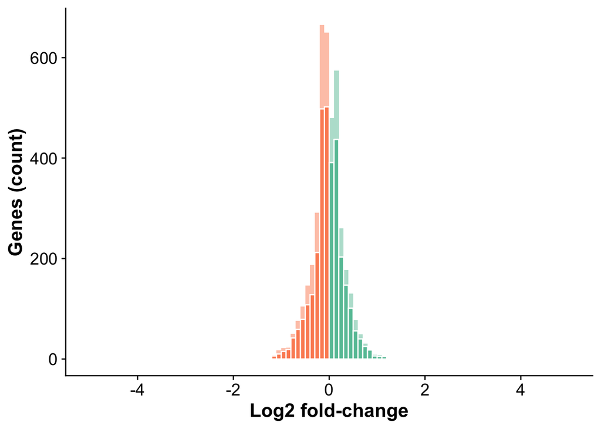

```r
#prepare a df for histogram of up- and down-regulated genes
df<-deseq.res %>%
  as.data.frame() %>%
  filter(!is.na(padj),padj <= 0.05) %>% #filter for significant genes
  rownames_to_column(var="gene")
max<-round(max(abs(df$log2FoldChange))) #get max value for x-axis
df$effect<-ifelse(df$log2FoldChange > 0,"Up-regulated","Down-regulated") #add effect column

#plot histogram of log2FoldChange
ggplot(df,aes(x=log2FoldChange,fill=effect)) +
  geom_histogram(binwidth=0.1,boundary=0,alpha=0.5) +
  geom_histogram(data=df %>% filter(gene %in% genes.aut),
                 binwidth=0.1,
                 boundary=0,
                 color="white")+
  scale_fill_brewer(palette="Set2",guide="none",direction = -1) +
  scale_x_continuous(limits=c(-5,5),breaks=scales::pretty_breaks())+
  scale_y_continuous(breaks=scales::pretty_breaks()) +
  theme_cowplot() +
  theme(axis.title=element_text(face="bold",size=16),
        axis.text=element_text(size=14)) +
  labs(x="Log2 fold-change",y="Genes (count)")
```

Just as we did above, we can also generate an MA plot that captures the relationship between mean expression and the DE effect estimates. Here, however, we’re using point size to capture information about whether a gene is autosomally localized.

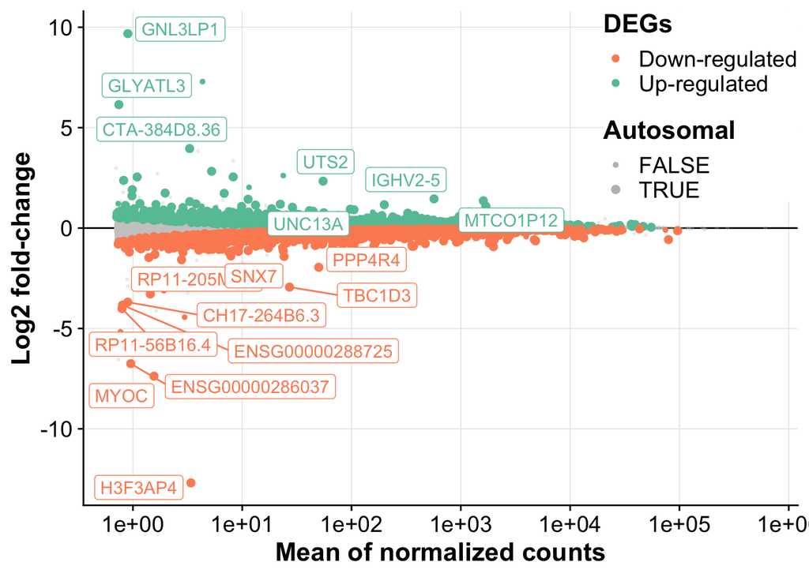

```r
#prep data for MA plot
AMR_df <- as.data.table(deseq.res) #convert to data.table
AMR_df$gene<-rownames(deseq.res) #add gene column
AMR_df<-AMR_df %>% dplyr::select(gene,colnames(AMR_df)[1:6]) #select relevant columns
AMR_df$autosomal<-FALSE #add autosomal column
AMR_df[gene %in% genes.aut,]$autosomal<-TRUE #set autosomal column to TRUE for autosomal genes
AMR_df$gene<-substr(AMR_df$gene,1,15) #shorten gene names
AMR_df$Symbol<-mapIds(EnsDb.Hsapiens.v86, keys=AMR_df$gene, column="SYMBOL", keytype="GENEID", multiVals="first") #add gene symbols
AMR_df[is.na(AMR_df$Symbol),]$Symbol<-AMR_df[is.na(AMR_df$Symbol),]$gene #fill in missing gene symbols

# annotate significantly DE genes
AMR_df$sig<-"none"
AMR_df[AMR_df$padj <= 0.05 & AMR_df$log2FoldChange > 0,]$sig<-"Up-regulated"
AMR_df[AMR_df$padj <= 0.05 & AMR_df$log2FoldChange < 0,]$sig<-"Down-regulated"

# annotate DE effect
AMR_df$effect<-"none"
AMR_df[AMR_df$padj <= 0.05 & AMR_df$log2FoldChange >= 2,]$effect<-"Up"
AMR_df[AMR_df$padj <= 0.05 & AMR_df$log2FoldChange <= -2,]$effect<-"Down"

#plot MA plot
ggplot() +
  geom_hline(yintercept=0) +
  geom_point(data = AMR_df %>% dplyr::filter(sig == "none",!is.na(padj)),
             mapping = aes(x=baseMean,
                           y=log2FoldChange),
             size=0.5,
             color="gray80",
             alpha=0.25) + #scatter plot background for non DE genes
  geom_point(data = AMR_df %>% dplyr::filter(sig == "Up-regulated"),
             mapping = aes(x=baseMean,
                           y=log2FoldChange,
                           color=sig,
                           size=autosomal),

             alpha=1) + #scatter plot foreground for up-regulated genes
  geom_point(data = AMR_df %>% dplyr::filter(sig == "Down-regulated"),
             mapping = aes(x=baseMean,
                           y=log2FoldChange,
                           color=sig,
                           size=autosomal),
             alpha=1) + #scatter plot foreground for down-regulated genes
  geom_label_repel(data = AMR_df %>%
               filter(padj <= 0.05,autosomal) %>%
               group_by(sig) %>%
               arrange(-abs(log2FoldChange),.by_group = T) %>%
               slice_max(n=20,order_by = abs(log2FoldChange)),
             aes(label=Symbol,color=sig,x=baseMean,y=log2FoldChange),
             show.legend=F) + #labels for the top 20 DEGs (per up- and down-regulated)
  scale_x_continuous(trans='log10',
                     breaks=10^seq(-3,10)) +
  scale_size_manual(values=c(1,2)) +
  scale_color_brewer(palette="Set2",direction=-1) +
  theme_cowplot() +
  theme(panel.grid.major = element_line(color="gray90",
                                        linewidth=0.25),
        legend.position = c(1,1),
        legend.justification = c("right","top"),
        legend.box.background = element_rect(fill="white",color="transparent"),
        legend.title = element_text(face="bold",size=16),
        legend.text=element_text(size=14),
        axis.title=element_text(face="bold",size=16),
        axis.text=element_text(size=14)) +
  guides(size = guide_legend(override.aes = list(color="gray",alpha=1)),
         color = guide_legend(override.aes = list(shape=16,alpha=1,size=2))) +
  labs(x="Mean of normalized counts",
       y="Log2 fold-change",
       size="Autosomal",
       color="DEGs")
```

Finally, we can generate a volcano plot for the DE genes on autosomes. As before, `|log2FoldChange|` ≥ 2 is used as the threshold for a “large DE effect” for any given gene. Again, size is being used to distinguish autosomal genes from sex chromosome genes.

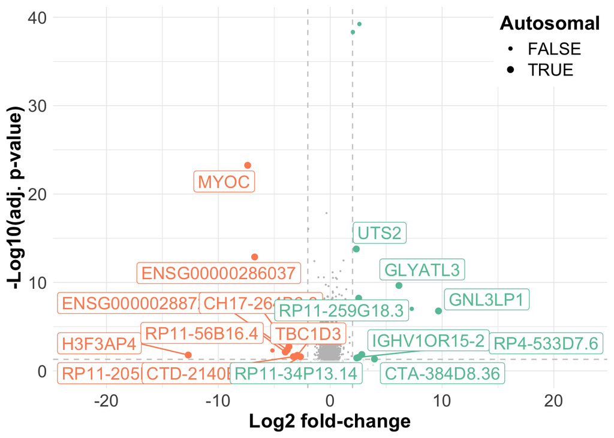

```r
#Volcano plot
ggplot(mapping = aes(x = log2FoldChange,
                     y = -log10(padj),
                     color = effect)) +
  geom_hline(yintercept=-log10(0.05),
             color="gray80",
             linewidth=0.5,
             linetype=2) + # significance threshold vline
  geom_vline(xintercept=c(-2,2),
             color="gray80",
             linewidth=0.5,
             linetype = 2) + # strong effect hlines
  geom_point(data=AMR_df %>% filter(!is.na(padj),sig == "none"),
             size=0.1,
             color="gray90") + # background scatter plot for non DE genes
    geom_point(data=AMR_df %>% filter(!is.na(padj),effect == "none",!sig=="none"),
             size=0.1,
             color="gray75") + # background scatter plot for DE, but small effect genes
  geom_point(data=AMR_df %>% filter(!is.na(padj),!effect == "none"),
             aes(size=autosomal)) + # foreground scatter plot for strong effect DE genes
  geom_label_repel(data = AMR_df %>%
               filter(padj <= 0.05,autosomal,!effect == "none") %>%
               group_by(sig) %>%
               arrange(-abs(log2FoldChange),.by_group = T) %>%
               slice_max(n=20,order_by = abs(log2FoldChange)),
                  mapping = aes(label = Symbol),
                  max.overlaps = 100,
                  size=5) + #labels for the top 20 DEGs (per up- and down-regulated)
  scale_size_manual(values=c(1,2)) +
  scale_x_continuous(limits=c(-max(abs(AMR_df$log2FoldChange),na.rm = T),
                              max(abs(AMR_df$log2FoldChange),na.rm = T))) +
  scale_color_manual(values = c("none" = "gray75",
                                "Up"="#66C2A5",
                                "Down"="#FC8D62"),
                     guide="none") +
  theme_minimal() +
theme(panel.grid.major = element_line(color="gray90",
                                        linewidth=0.25),
        legend.position = c(1,1),
        legend.justification = c("right","top"),
        legend.box.background = element_rect(fill="white",color="transparent"),
        legend.title = element_text(face="bold",size=16),
        legend.text=element_text(size=14),
        axis.title=element_text(face="bold",size=16),
        axis.text=element_text(size=14)) +
  labs(x="Log2 fold-change",
       y="-Log10(adj. p-value)",
       size="Autosomal")
```